# Consumo de Gasolina

#### Estimación

Como no es estacionaria en varianza se hizo una transformación logarítmica para hacer que sea estacionaria en varianza. Se realizó con la serie de entrenamiento que es la que nos ayudará a predecir.

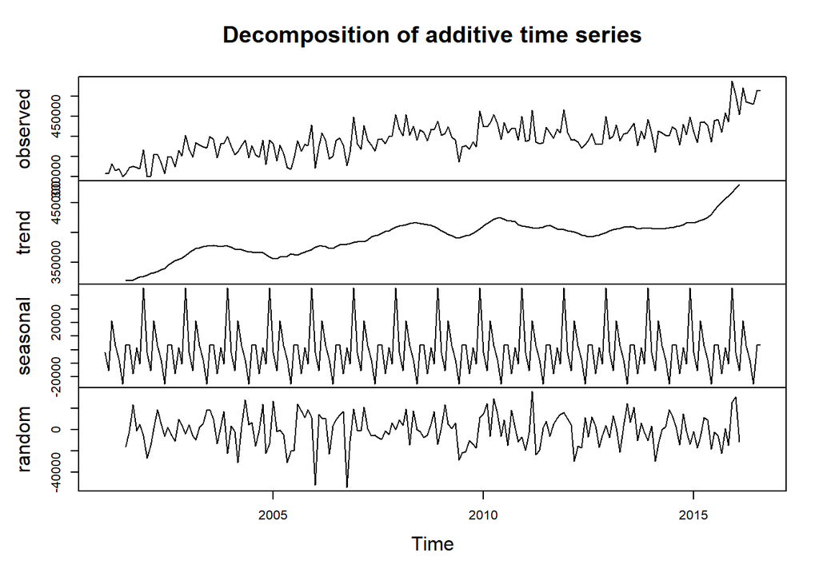

```r
train<-head(super_ts, round(length(super_ts) * 0.7))
h<-length(super_ts) - length(train)
test<-tail(super_ts, h)

#Aplicaremos una transformación logarítmica
logSuper<-log(train)
plot(decompose(train))
```

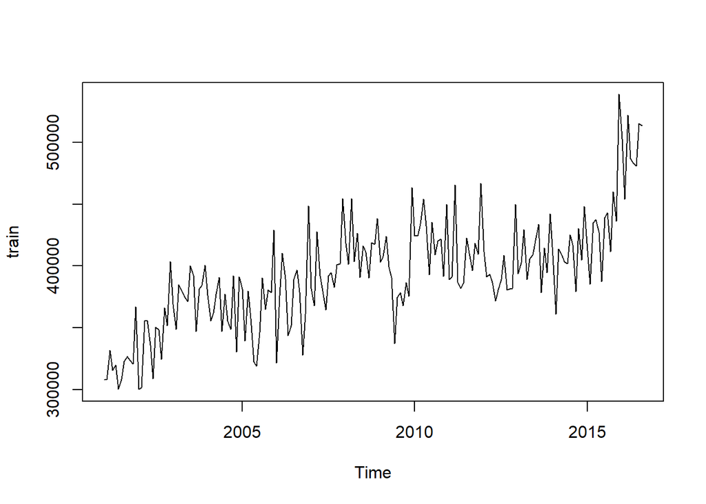

```r
plot(train)
```

```r
#Para saber si hay raíces unitarias
adfTest(train)
```

```
##
## Title:
##  Augmented Dickey-Fuller Test
##
## Test Results:
##   PARAMETER:
##     Lag Order: 1
##   STATISTIC:
##     Dickey-Fuller: 0.3636
##   P VALUE:
##     0.7309
##
## Description:
##  Mon Aug 08 23:41:28 2022 by user: xavih
```

```r
unitrootTest(train)
```

```
##
## Title:
##  Augmented Dickey-Fuller Test
##
## Test Results:
##   PARAMETER:
##     Lag Order: 1
##   STATISTIC:
##     DF: 0.3636
##   P VALUE:
##     t: 0.7886
##     n: 0.7722
##
## Description:
##  Mon Aug 08 23:41:28 2022 by user: xavih
```

Se observa que el valor de P es mayor a 0.05 por lo que la hipótesis nula no se rechaza, lo que significa que la serie no es estacionaria. Ahora aplicamos diferenciación.

```r
adfTest(diff(train))
```

```
##
## Title:
##  Augmented Dickey-Fuller Test
##
## Test Results:
##   PARAMETER:
##     Lag Order: 1
##   STATISTIC:
##     Dickey-Fuller: -18.3093
##   P VALUE:
##     0.01
##
## Description:
##  Mon Aug 08 23:41:28 2022 by user: xavih
```